# 57bb4a1f-2c9b-4e75-b452-00c8206dc72d

## Cодержание

- 1 Цель проекта
- 2 Знакомство с данными
  - 2.1 Phone_new
  - 2.2 Internet_new
  - 2.3 Personal_new
  - 2.4 Contract_new
- 3 Анализ ушедших клиентов
- 4 Сравнение ушедших и оставшихся клиентов
- 5 Промежуточный вывод №1
- 6 План работы
- 7 Предобработка данных
- 8 Выбор модели
- 9 Тестирование
  - 9.1 ROC-CURVE
  - 9.2 Матрица ошибок
  - 9.3 Анализ важности признаков
- 10 Промежуточный вывод №2
- 11 Отчет по решению

# Предсказание оттока клиентов в сфере телекоммуникаций

## Цель

Целью проекта является получить наиболее подходящую по результатам и затратам ресурсов модель для предсказаний оттока клиентов для телекоммуникационной компании.

## Знакомство с данными

- MultipleLines - наличие возможности ведения параллельных линий во время звонка
- InternetService - наличие интернет-услуг
- OnlineSecurity - наличие защиты от небезопасных сайтов
- OnlineBackup - наличие облачного хранилища файлов для резервного копирования данных
- DeviceProtection - наличие антивируса для устройства
- TechSupport - наличие выделенной линии технической поддержки
- StreamingTV - наличие стриминг-телевидения
- StreamingMovies - наличие онлайн кинотеатра
- gender - пол
- SeniorCitizen - наличие пенсионного статуса по возрасту
- Partner - наличие партнера
- Dependents - наличие иждивенцов
- BeginDate - дата начала действия контракта
- EndDate - дата окончания действия контракта
- Type - тип оплаты
- PaperlessBilling - наличие элеткронного платежного документа
- PaymentMethod - способ оплаты
- MonthlyCharges - ежемесячный платеж
- TotalCharges - сумма платежей за все время

```python
!pip install scikit-learn==1.1.3
!pip install phik
!pip install shap
```

```python
# импорт библиотек
import pandas as pd
import numpy as np
import seaborn as sns
import matplotlib.pyplot as plt

# sklearn
from sklearn.model_selection import (
    GridSearchCV,
    RandomizedSearchCV,
    train_test_split
)
from sklearn.preprocessing import (
    OneHotEncoder,
    OrdinalEncoder,
    StandardScaler
)
from sklearn.metrics import (
    accuracy_score,
    roc_auc_score,
    roc_curve,
    confusion_matrix,
    ConfusionMatrixDisplay
)
from sklearn.pipeline import make_pipeline
from sklearn.compose import make_column_transformer
from sklearn.linear_model import LogisticRegression

# анализ моделей и данных
import phik
import shap

# catboost
from catboost import CatBoostClassifier
```

```python
#загрузка данных
try:
    phone = pd.read_csv('C:/Users/pashu/Downloads/phone_new.csv', index_col = 'customerID')
    internet = pd.read_csv('C:/Users/pashu/Downloads/internet_new.csv', index_col = 'customerID')
    personal = pd.read_csv('C:/Users/pashu/Downloads/personal_new.csv', index_col = 'customerID')
    contract = pd.read_csv('C:/Users/pashu/Downloads/contract_new.csv', index_col = 'customerID')
except:

    phone = pd.read_csv('/datasets/phone_new.csv', index_col = 'customerID')
    internet = pd.read_csv('/datasets/internet_new.csv', index_col = 'customerID')
    personal = pd.read_csv('/datasets/personal_new.csv', index_col = 'customerID')
    contract = pd.read_csv('/datasets/contract_new.csv', index_col = 'customerID')
```

### Phone_new

```python
phone.head()
```

| customerID | MultipleLines |
| --- | --- |
| 5575-GNVDE | No |
| 3668-QPYBK | No |
| 9237-HQITU | No |
| 9305-CDSKC | Yes |
| 1452-KIOVK | Yes |

```python
phone.info()
```

```
<class 'pandas.core.frame.DataFrame'>
Index: 6361 entries, 5575-GNVDE to 3186-AJIEK
Data columns (total 1 columns):
 #   Column         Non-Null Count  Dtype
---  ------         --------------  -----
 0   MultipleLines  6361 non-null   object
dtypes: object(1)
memory usage: 99.4+ KB
```

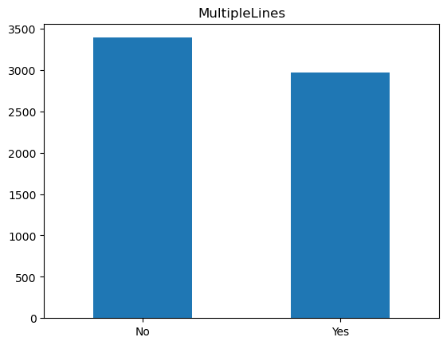

```python
phone['MultipleLines'].value_counts().plot.bar(rot=0, title = 'MultipleLines')
```

Большинство клиентов не пользуется данной функцией, хотя достаточно большая часть делает обратное. Возможно, уходящим клиентам стоит рассказывать о ее наличии, так как она популярна.

### Internet_new

```python
internet.head()
```

| customerID | InternetService | OnlineSecurity | OnlineBackup | DeviceProtection | TechSupport | StreamingTV | StreamingMovies |
| --- | --- | --- | --- | --- | --- | --- | --- |
| 7590-VHVEG | DSL | No | Yes | No | No | No | No |
| 5575-GNVDE | DSL | Yes | No | Yes | No | No | No |
| 3668-QPYBK | DSL | Yes | Yes | No | No | No | No |
| 7795-CFOCW | DSL | Yes | No | Yes | Yes | No | No |
| 9237-HQITU | Fiber optic | No | No | No | No | No | No |

```python
internet.info()
```

```
<class 'pandas.core.frame.DataFrame'>
Index: 5517 entries, 7590-VHVEG to 3186-AJIEK
Data columns (total 7 columns):
 #   Column            Non-Null Count  Dtype
---  ------            --------------  -----
 0   InternetService   5517 non-null   object
 1   OnlineSecurity    5517 non-null   object
 2   OnlineBackup      5517 non-null   object
 3   DeviceProtection  5517 non-null   object
 4   TechSupport       5517 non-null   object
 5   StreamingTV       5517 non-null   object
 6   StreamingMovies   5517 non-null   object
dtypes: object(7)
memory usage: 344.8+ KB
```

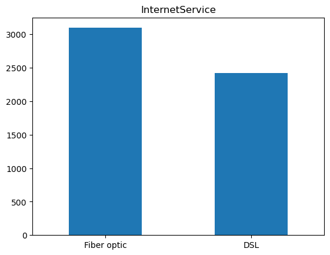

```python
internet['InternetService'].value_counts().plot.bar(rot=0, title = 'InternetService')
```

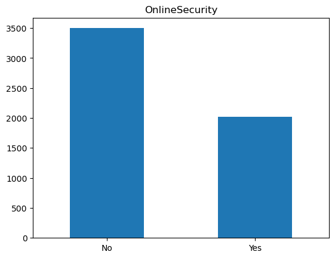

```python
internet['OnlineSecurity'].value_counts().plot.bar(rot=0, title = 'OnlineSecurity')
```

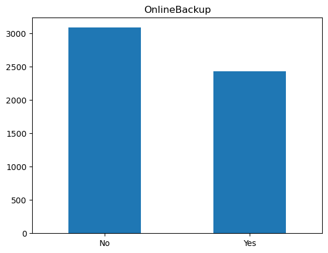

```python
internet['OnlineBackup'].value_counts().plot.bar(rot=0, title = 'OnlineBackup')
```

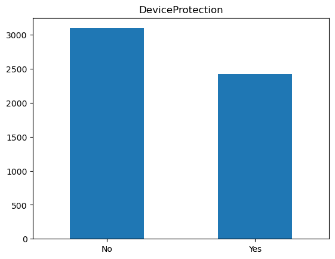

```python
internet['DeviceProtection'].value_counts().plot.bar(rot=0, title = 'DeviceProtection')
```

Защита данных и своего устройства в настоящие время является крайне важным и необходимым условием безопасного использования девайсов, но большинство клиентов не используют эти функции. Также стоит донести для них об их существовании.

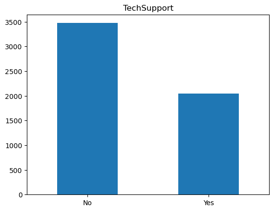

```python
internet['TechSupport'].value_counts().plot.bar(rot=0, title = 'TechSupport')
```

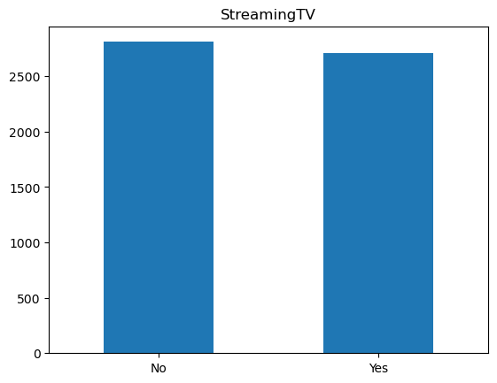

```python
internet['StreamingTV'].value_counts().plot.bar(rot=0, title = 'StreamingTV')
```

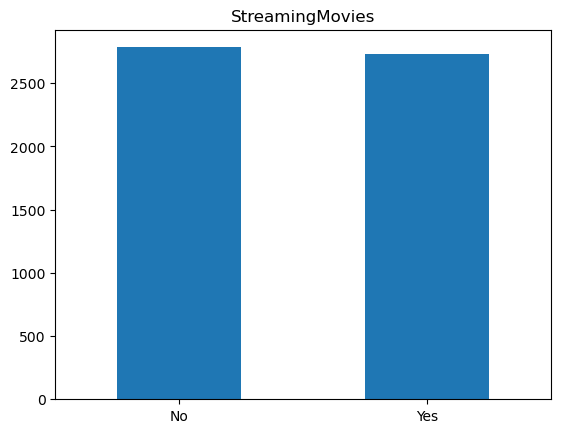

```python
internet['StreamingMovies'].value_counts().plot.bar(rot=0, title = 'StreamingMovies')
```

Клиенты пользуются стримингами примерно 50 на 50, функция тоже крайне популярна. Возможно, именно на нее можно выдавать промокод

### Personal_new

```python
personal.head()
```

| customerID | gender | SeniorCitizen | Partner | Dependents |
| --- | --- | --- | --- | --- |
| 7590-VHVEG | Female | 0 | Yes | No |
| 5575-GNVDE | Male | 0 | No | No |
| 3668-QPYBK | Male | 0 | No | No |
| 7795-CFOCW | Male | 0 | No | No |
| 9237-HQITU | Female | 0 | No | No |

```python
personal.info()
```

```
<class 'pandas.core.frame.DataFrame'>
Index: 7043 entries, 7590-VHVEG to 3186-AJIEK
Data columns (total 4 columns):
 #   Column         Non-Null Count  Dtype
---  ------         --------------  -----
 0   gender         7043 non-null   object
 1   SeniorCitizen  7043 non-null   int64
 2   Partner        7043 non-null   object
 3   Dependents     7043 non-null   object
dtypes: int64(1), object(3)
memory usage: 275.1+ KB
```

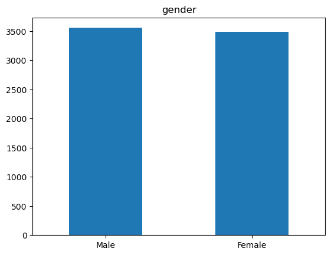

```python
personal['gender'].value_counts().plot.bar(rot=0, title = 'gender')
```

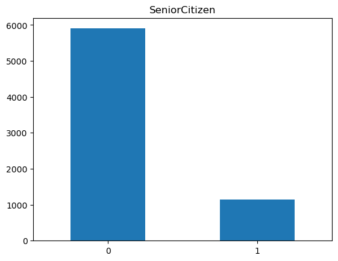

```python
personal['SeniorCitizen'].value_counts().plot.bar(rot=0, title = 'SeniorCitizen')
```

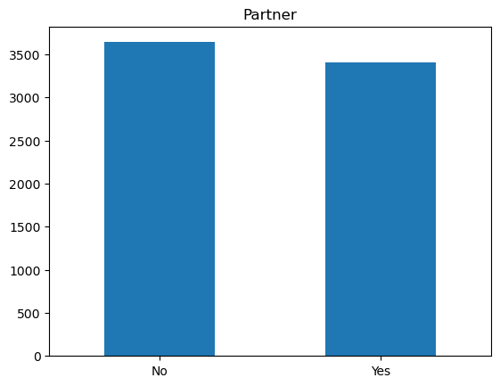

```python
personal['Partner'].value_counts().plot.bar(rot=0, title = 'Partner')
```

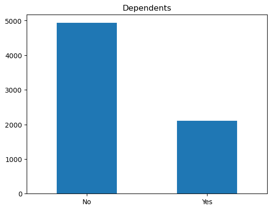

```python
personal['Dependents'].value_counts().plot.bar(rot=0, title = 'Dependents')
```

Среди клиентов много таких, кому не помешали бы "семейные пакеты услуг" или социальные скидки.

### Contract_new

```python
contract.head()
```

| customerID | BeginDate | EndDate | Type | PaperlessBilling | PaymentMethod | MonthlyCharges | TotalCharges |
| --- | --- | --- | --- | --- | --- | --- | --- |
| 7590-VHVEG | 2020-01-01 | No | Month-to-month | Yes | Electronic check | 29.85 | 31.04 |
| 5575-GNVDE | 2017-04-01 | No | One year | No | Mailed check | 56.95 | 2071.84 |
| 3668-QPYBK | 2019-10-01 | No | Month-to-month | Yes | Mailed check | 53.85 | 226.17 |
| 7795-CFOCW | 2016-05-01 | No | One year | No | Bank transfer (automatic) | 42.30 | 1960.6 |
| 9237-HQITU | 2019-09-01 | No | Month-to-month | Yes | Electronic check | 70.70 | 353.5 |

```python
contract.info()
```

```
<class 'pandas.core.frame.DataFrame'>
Index: 7043 entries, 7590-VHVEG to 3186-AJIEK
Data columns (total 7 columns):
 #   Column            Non-Null Count  Dtype
---  ------            --------------  -----
 0   BeginDate         7043 non-null   object
 1   EndDate           7043 non-null   object
 2   Type              7043 non-null   object
 3   PaperlessBilling  7043 non-null   object
 4   PaymentMethod     7043 non-null   object
 5   MonthlyCharges    7043 non-null   float64
 6   TotalCharges      7043 non-null   object
dtypes: float64(1), object(6)
memory usage: 440.2+ KB
```

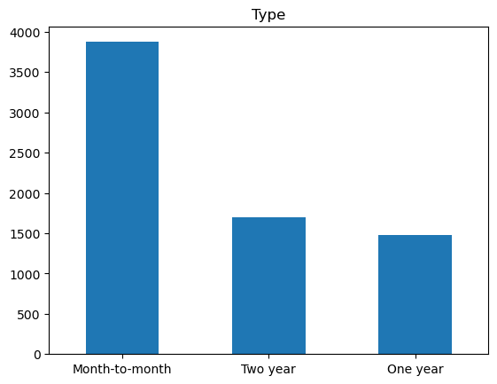

```python
contract['Type'].value_counts().plot.bar(rot=0, title = 'Type')
```

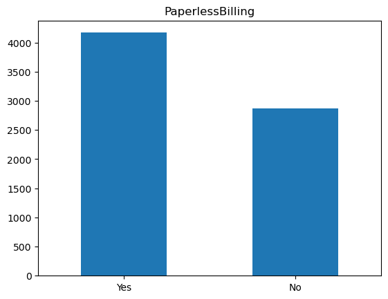

```python
contract['PaperlessBilling'].value_counts().plot.bar(rot=0, title = 'PaperlessBilling')
```

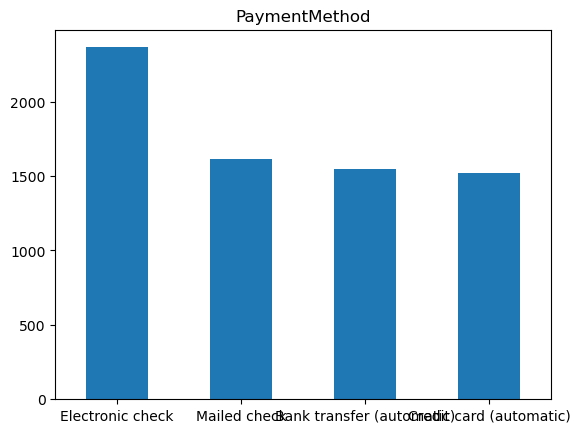

```python
contract['PaymentMethod'].value_counts().plot.bar(rot=0, title = 'PaymentMethod')
```

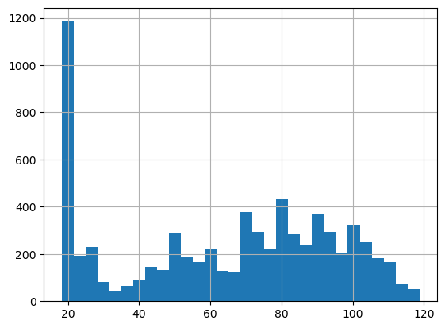

```python
contract['MonthlyCharges'].hist(bins=30)
```

```python
# объединяем все данные в одну таблицу
data_all = pd.concat([phone, internet, personal, contract], axis = 1)
```

## Анализ ушедших клиентов

```python
# отбираем клиентов, которые ушли от компании
data_no = data_all[data_all['EndDate'] != 'No']
```

```python
data_no.info()
```

```
<class 'pandas.core.frame.DataFrame'>
Index: 1101 entries, 6388-TABGU to 4501-VCPFK
Data columns (total 19 columns):
 #   Column            Non-Null Count  Dtype
---  ------            --------------  -----
 0   MultipleLines     998 non-null    object
 1   InternetService   941 non-null    object
 2   OnlineSecurity    941 non-null    object
 3   OnlineBackup      941 non-null    object
 4   DeviceProtection  941 non-null    object
 5   TechSupport       941 non-null    object
 6   StreamingTV       941 non-null    object
 7   StreamingMovies   941 non-null    object
 8   gender            1101 non-null   object
 9   SeniorCitizen     1101 non-null   int64
 10  Partner           1101 non-null   object
 11  Dependents        1101 non-null   object
 12  BeginDate         1101 non-null   object
 13  EndDate           1101 non-null   object
 14  Type              1101 non-null   object
 15  PaperlessBilling  1101 non-null   object
 16  PaymentMethod     1101 non-null   object
 17  MonthlyCharges    1101 non-null   float64
 18  TotalCharges      1101 non-null   object
dtypes: float64(1), int64(1), object(17)
memory usage: 172.0+ KB
```

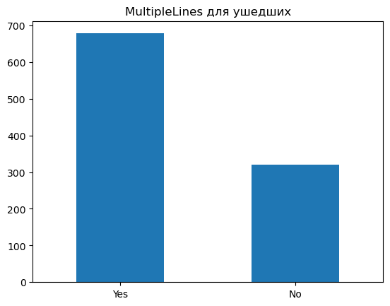

```python
data_no['MultipleLines'].value_counts().plot.bar(rot=0, title = 'MultipleLines для ушедших')
```

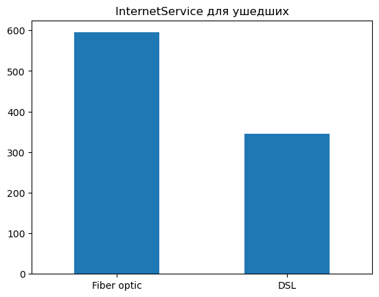

```python
data_no['InternetService'].value_counts().plot.bar(rot=0, title = 'InternetService для ушедших')
```

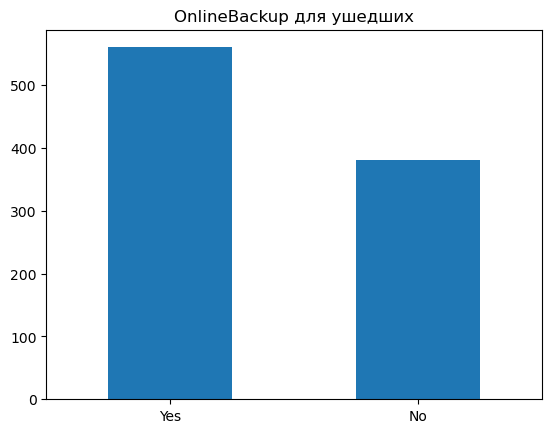

```python
data_no['OnlineBackup'].value_counts().plot.bar(rot=0, title = 'OnlineBackup для ушедших')
```

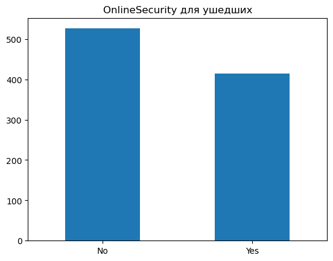

```python
data_no['OnlineSecurity'].value_counts().plot.bar(rot=0, title = 'OnlineSecurity для ушедших')
```

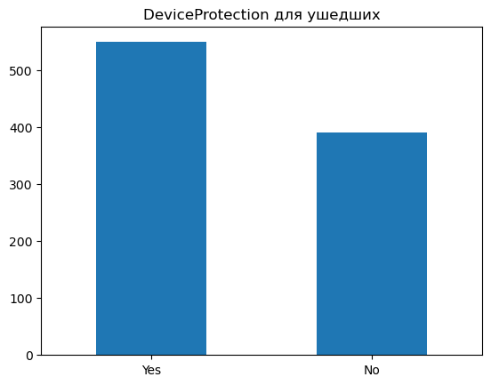

```python
data_no['DeviceProtection'].value_counts().plot.bar(rot=0, title = 'DeviceProtection для ушедших')
```

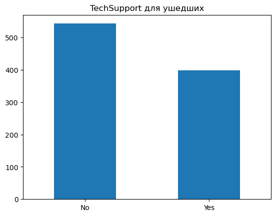

```python
data_no['TechSupport'].value_counts().plot.bar(rot=0, title = 'TechSupport для ушедших')
```

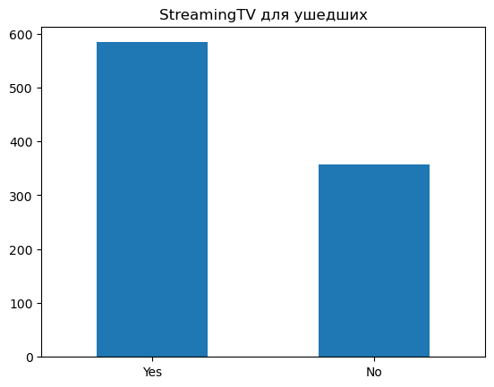

```python
data_no['StreamingTV'].value_counts().plot.bar(rot=0, title = 'StreamingTV для ушедших')
```

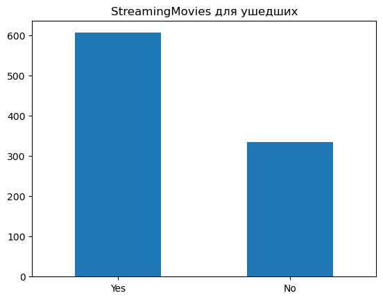

```python
data_no['StreamingMovies'].value_counts().plot.bar(rot=0, title = 'StreamingMovies для ушедших')
```

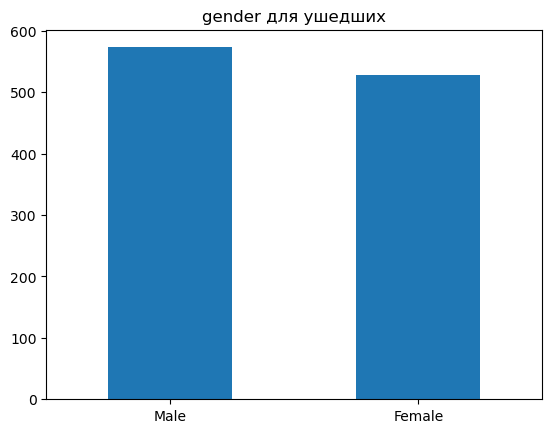

```python
data_no['gender'].value_counts().plot.bar(rot=0, title = 'gender для ушедших')
```

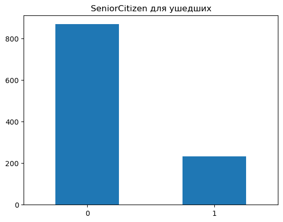

```python
data_no['SeniorCitizen'].value_counts().plot.bar(rot=0, title = 'SeniorCitizen для ушедших')
```

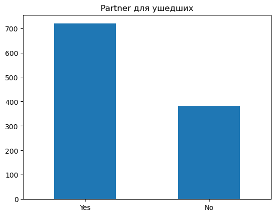

```python
data_no['Partner'].value_counts().plot.bar(rot=0, title = 'Partner для ушедших')
```

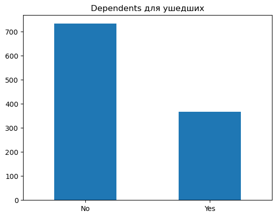

```python
data_no['Dependents'].value_counts().plot.bar(rot=0, title = 'Dependents для ушедших')
```

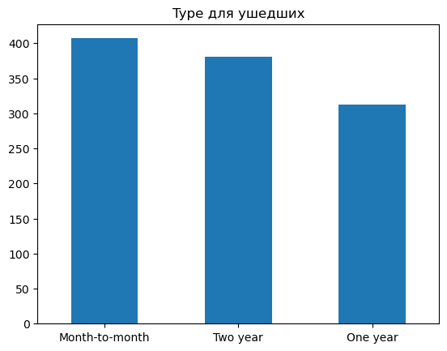

```python
data_no['Type'].value_counts().plot.bar(rot=0, title = 'Type для ушедших')
```

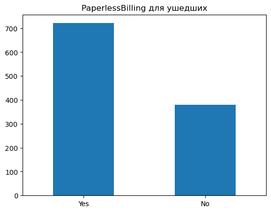

```python
data_no['PaperlessBilling'].value_counts().plot.bar(rot=0, title = 'PaperlessBilling для ушедших')
```

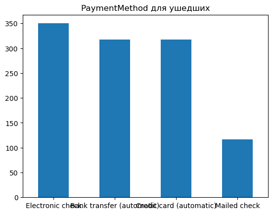

```python
data_no['PaymentMethod'].value_counts().plot.bar(rot=0, title = 'PaymentMethod для ушедших')
```

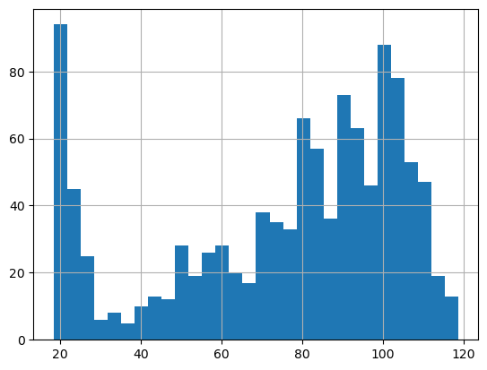

```python
data_no['MonthlyCharges'].hist(bins=30)
```